# Basic use cases of the `nonprobsvy` package

# 3 Mass imputation estimator

Now, we start with [mass imputation estimator](https://ncn-foreigners.github.io/nonprobsvy-book/mi.html) under different settings.

## 3.1 Only population information is available

In the examples we assume that $f(Y|X)$ is linear so the estimator will be biased as model is mis-specified.

```r
mi_poptotals <- nonprob(outcome = Y ~ X3 + X4 + X5 + X6,
                        data = sample_B,
                        pop_totals = X_totals[c("(Intercept)", "X3", "X4", "X5", "X6")],
                        method_outcome = "glm",
                        family_outcome = "gaussian")

cbind(mi_poptotals$output,mi_poptotals$confidence_interval)
```

|  | mean | SE | lower_bound | upper_bound |
| --- | --- | --- | --- | --- |
| Y | 2.030164 | 0.0282608 | 1.974774 | 2.085555 |

## 3.2 Probability sample is available

Now, consider that sample

```r
mi_sample <- nonprob(outcome = Y ~ X3 + X4 + X5 + X6,
                     data = sample_B,
                     svydesign = sample_A_svy_cal,
                     method_outcome = "glm",
                     family_outcome = "gaussian")

cbind(mi_sample$output,mi_sample$confidence_interval)
```

|  | mean | SE | lower_bound | upper_bound |
| --- | --- | --- | --- | --- |
| Y | 2.030164 | 0.1111 | 1.812412 | 2.247916 |

We can select variables using SCAD penalty.

```r
mi_sample_scad <- nonprob(outcome = Y ~ X1 + X2 + X3 + X4 + X5 + X6 + X7 + X8 + X9 + X10,
                          data = sample_B,
                          svydesign = sample_A_svy_cal,
                          method_outcome = "glm",
                          family_outcome = "gaussian",
                          control_outcome = controlOut(penalty = "SCAD"),
                          control_inference = controlInf(vars_selection = TRUE))

cbind(mi_sample_scad$output,mi_sample_scad$confidence_interval)
```

|  | mean | SE | lower_bound | upper_bound |
| --- | --- | --- | --- | --- |
| Y | 2.030164 | 0.1111 | 1.812412 | 2.247916 |

We can change to nearest neighbour imputation estimator but note that we use all X not predictive mean matching.

```r
mi_sample_nn <- nonprob(outcome = Y ~ X3 + X4 + X5 + X6,
                        data = sample_B,
                        svydesign = sample_A_svy_cal,
                        method_outcome = "nn",
                        family_outcome = "gaussian",
                        control_outcome = controlOut(k = 3))

cbind(mi_sample_nn$output,mi_sample_nn$confidence_interval)
```

|  | mean | SE | lower_bound | upper_bound |
| --- | --- | --- | --- | --- |
| Y | 2.174309 | 0.0959102 | 1.986328 | 2.362289 |

We can specify variance to boostrap

```r
mi_sample_nn <- nonprob(outcome = Y ~ X3 + X4 + X5 + X6,
                        data = sample_B,
                        svydesign = sample_A_svy_cal,
                        method_outcome = "nn",
                        family_outcome = "gaussian",
                        control_outcome = controlOut(k = 3),
                        control_inference = controlInf(var_method = "bootstrap", num_boot = 50))

cbind(mi_sample_nn$output,mi_sample_nn$confidence_interval)
```

|  | mean | SE | lower_bound | upper_bound |
| --- | --- | --- | --- | --- |
| Y | 2.179253 | 0.1091823 | 1.96526 | 2.393246 |

# 4 Doubly robust estimator

Finally, we present [doubly robust estimator](https://ncn-foreigners.github.io/nonprobsvy-book/dr.html) under different settings.

## 4.1 Only population information is available

Consider the case when only population information is available

```r
dr_logit_poptotals <- nonprob(selection = ~ X1 + X2 + X3 + X4,
                              outcome = Y ~ X1 + X2 + X3 + X4,
                              data = sample_B,
                              pop_totals = X_totals[1:5],
                              method_selection = "logit")

cbind(dr_logit_poptotals$output,dr_logit_poptotals$confidence_interval)
```

|  | mean | SE | lower_bound | upper_bound |
| --- | --- | --- | --- | --- |
| Y | 2.182047 | 0.0795395 | 2.026152 | 2.337942 |

We can apply `gee` with `h=1`

```r
dr_logit_poptotals_gee <- nonprob(selection = ~ X1 + X2 + X3 + X4,
                                  outcome = Y ~ X1 + X2 + X3 + X4,
                                  data = sample_B,
                                  pop_totals = X_totals[1:5],
                                  method_selection = "logit",
                                  control_selection = controlSel(est_method_sel = "gee", h = 1))

cbind(dr_logit_poptotals_gee$output,dr_logit_poptotals_gee$confidence_interval)
```

|  | mean | SE | lower_bound | upper_bound |
| --- | --- | --- | --- | --- |
| Y | 2.182047 | 0.0697033 | 2.045431 | 2.318663 |

Finally, we can coduct variable selection

```r
dr_logit_poptotals_scad <- nonprob(selection = ~ X1 + X2 + X3 + X4 + X5 + X6 + X7 + X8 + X9 + X10 + X11,
                                   outcome = Y ~ X1 + X2 + X3 + X4 + X5 + X6 + X7 + X8 + X9 + X10 + X12,
                                   data = sample_B,
                                   pop_totals = X_totals[1:13],
                                   method_selection = "logit",
                                   control_inference = controlInf(vars_selection = TRUE))

cbind(dr_logit_poptotals_scad$output, dr_logit_poptotals_scad$confidence_interval)
```

|  | mean | SE | lower_bound | upper_bound |
| --- | --- | --- | --- | --- |
| Y | 2.106232 | 0.0397679 | 2.028288 | 2.184176 |

Note that we apply union of variables after variable selection.

```r
data.frame(sel = dr_logit_poptotals_scad$selection$coefficients,
           out = dr_logit_poptotals_scad$outcome$coefficients)
```

|  | sel | out |
| --- | --- | --- |
| (Intercept) | -1.7484126 | 2.0475889 |
| X1 | 1.0023615 | -0.0251186 |
| X3 | 0.9302272 | 0.9795060 |
| X4 | 1.0459029 | 0.9647523 |
| X5 | 0.0285979 | 1.0123188 |
| X6 | -0.0034868 | 1.0474544 |
| X8 | -0.0615370 | -0.0539106 |

## 4.2 Probability sample is available

Now consider situation when probability sample is available

```r
dr_logit_sample <- nonprob(selection = ~ X1 + X2 + X3 + X4,
                           outcome = Y ~ X1 + X2 + X3 + X4,
                           data = sample_B,
                           svydesign = sample_A_svy_cal,
                           method_selection = "logit")

cbind(dr_logit_sample$output,dr_logit_sample$confidence_interval)
```

|  | mean | SE | lower_bound | upper_bound |
| --- | --- | --- | --- | --- |
| Y | 2.227171 | 0.1982169 | 1.838673 | 2.615669 |

Now use `gee` with `h=1` with bootstrap.

```r
dr_logit_sample_gee <- nonprob(selection = ~ X1 + X2 + X3 + X4,
                               outcome = Y ~ X1 + X2 + X3 + X4,
                               data = sample_B,
                               svydesign = sample_A_svy_cal,
                               method_selection = "logit",
                               control_selection = controlSel(est_method_sel = "gee", h = 1),
                               control_inference = controlInf(var_method = "bootstrap", num_boot = 50),
                               verbose = TRUE)
```

```
[1] "iteration 1/50, estimated mean = 2.05603192866914"
[1] "iteration 2/50, estimated mean = 2.11894736019864"
[1] "iteration 3/50, estimated mean = 2.07960656746253"
[1] "iteration 4/50, estimated mean = 2.25995594288392"
[1] "iteration 5/50, estimated mean = 2.24558747829909"
[1] "iteration 6/50, estimated mean = 2.16244283758057"
[1] "iteration 7/50, estimated mean = 2.29361873861236"
[1] "iteration 8/50, estimated mean = 2.2847874811103"
[1] "iteration 9/50, estimated mean = 2.14899258450824"
[1] "iteration 10/50, estimated mean = 2.30566480919169"
[1] "iteration 11/50, estimated mean = 2.18675952753041"
[1] "iteration 12/50, estimated mean = 2.20484676095901"
[1] "iteration 13/50, estimated mean = 1.97864133400368"
[1] "iteration 14/50, estimated mean = 2.24474229211648"
[1] "iteration 15/50, estimated mean = 2.18649428223022"
```

[output cut: 35 more lines]

```r
cbind(dr_logit_sample_gee$output,dr_logit_sample_gee$confidence_interval)
```

|  | mean | SE | lower_bound | upper_bound |
| --- | --- | --- | --- | --- |
| Y | 2.155421 | 0.0911773 | 1.976717 | 2.334125 |

We can also use bias minimization method as proposed in Yang, Kim, and Song (2020) by setting `bias_correction = TRUE`.

```r
dr_logit_sample_mm <- nonprob(selection = ~ X1 + X2 + X3 + X4,
                              outcome = Y ~ X1 + X2 + X3 + X4,
                              data = sample_B,
                              svydesign = sample_A_svy_cal,
                              method_selection = "logit",
                              verbose = TRUE,
                              control_inference = controlInf(var_method = "bootstrap",
                                                             num_boot = 50,
                                                             bias_correction = TRUE))
```

```
[1] "iteration 1/50, estimated mean = 2.31589217049563"
[1] "iteration 2/50, estimated mean = 2.28820347216497"
[1] "iteration 3/50, estimated mean = 2.20748093246756"
[1] "iteration 4/50, estimated mean = 2.34339095005789"
[1] "iteration 5/50, estimated mean = 2.19333525178175"
[1] "iteration 6/50, estimated mean = 2.12671793235237"
[1] "iteration 7/50, estimated mean = 2.25463892425984"
[1] "iteration 8/50, estimated mean = 2.0724397642215"
[1] "iteration 9/50, estimated mean = 2.1167598053459"
[1] "iteration 10/50, estimated mean = 1.9385063771011"
[1] "iteration 11/50, estimated mean = 2.06782009208292"
[1] "iteration 12/50, estimated mean = 2.21252911714036"
[1] "iteration 13/50, estimated mean = 2.06700023220175"
[1] "iteration 14/50, estimated mean = 2.10128599874739"
[1] "iteration 15/50, estimated mean = 2.28810975051204"
```

[output cut: 35 more lines]

```r
cbind(dr_logit_sample_mm$output,dr_logit_sample_mm$confidence_interval)
```

|  | mean | SE | lower_bound | upper_bound |
| --- | --- | --- | --- | --- |
| Y | 2.18579 | 0.1092476 | 1.971669 | 2.399911 |

We can apply variable selection (`SCAD`)

```r
dr_logit_sample_scad <- nonprob(selection = ~ X1 + X2 + X3 + X4 + X5 + X6 + X7 + X8 + X9 + X10,
                                outcome = Y ~ X1 + X2 + X3 + X4 + X5 + X6 + X7 + X8 + X9 + X10,
                                data = sample_B,
                                svydesign = sample_A_svy_cal,
                                method_selection = "logit",
                                control_selection = controlSel(penalty = "SCAD"),
                                control_inference = controlInf(vars_selection = TRUE))

cbind(dr_logit_sample_scad$output, dr_logit_sample_scad$confidence_interval)
```

|  | mean | SE | lower_bound | upper_bound |
| --- | --- | --- | --- | --- |
| Y | 2.141323 | 0.1277067 | 1.891023 | 2.391624 |

Finally, we can apply method proposed by Yang, Kim, and Song (2020), i.e. variable selection using SCAD and bias minimization after selection.

```r
dr_logit_sample_mm_scad <- nonprob(selection = ~ X1 + X2 + X3 + X4 + X5 + X6 + X7 + X8 + X9 + X10,
                                    outcome = Y ~ X1 + X2 + X3 + X4 + X5 + X6 + X7 + X8 + X9 + X10,
                                    data = sample_B,
                                    svydesign = sample_A_svy_cal,
                                    method_selection = "logit",
                                    control_selection = controlSel(penalty = "SCAD"),
                                    control_inference = controlInf(vars_selection = TRUE,
                                                                   bias_correction = TRUE))

cbind(dr_logit_sample_mm_scad$output, dr_logit_sample_mm_scad$confidence_interval)
```

|  | mean | SE | lower_bound | upper_bound |
| --- | --- | --- | --- | --- |
| Y | 2.152192 | 0.1093821 | 1.937807 | 2.366577 |

# 5 Summary

Now combine estimates from all models

```r
tab_res <- rbind(
  cbind(est="ipw with poptotals", ipw_logit_poptotals$output,ipw_logit_poptotals$confidence_interval),
  cbind(est="ipw with poptotals (gee h=1)", ipw_logit_poptotals_gee$output,ipw_logit_poptotals_gee$confidence_interval),
  cbind(est="ipw with poptotals SCAD", ipw_logit_poptotals_scad$output,ipw_logit_poptotals_scad$confidence_interval),
  cbind(est="ipw with sample", ipw_logit_sample$output,ipw_logit_sample$confidence_interval),
  cbind(est="ipw with sample (gee h=1)" , ipw_logit_sample_gee$output,ipw_logit_sample_gee$confidence_interval),
  cbind(est="ipw with sample (gee h=1 bootstrap)" , ipw_logit_sample_gee_boot$output,ipw_logit_sample_gee_boot$confidence_interval),
  cbind(est="ipw with sample SCAD" , ipw_logit_sample_scad$output,ipw_logit_sample_scad$confidence_interval),
  cbind(est="mi with poptotals" , mi_poptotals$output,mi_poptotals$confidence_interval),
  cbind(est="mi with sample (glm)" , mi_sample$output,mi_sample$confidence_interval),
  cbind(est="mi with sample (nn)" , mi_sample_nn$output,mi_sample_nn$confidence_interval),
  cbind(est="dr with poptotals" , dr_logit_poptotals$output,dr_logit_poptotals$confidence_interval),
  cbind(est="dr with poptotals (gee h=1)" , dr_logit_poptotals_gee$output,dr_logit_poptotals_gee$confidence_interval),
  cbind(est="dr with poptotals SCAD" , dr_logit_poptotals_scad$output,dr_logit_poptotals_scad$confidence_interval),
  cbind(est="dr with sample (glm)" , dr_logit_sample$output,dr_logit_sample$confidence_interval),
  cbind(est="dr with sample (gee h=1)" , dr_logit_sample_gee$output,dr_logit_sample_gee$confidence_interval),
  cbind(est="dr with sample (bias min)" , dr_logit_sample_mm$output,dr_logit_sample_mm$confidence_interval),
  cbind(est="dr with sample (bias min) SCAD", dr_logit_sample_mm_scad$output, dr_logit_sample_mm_scad$confidence_interval)
)

tab_res
```

|  | est | mean | SE | lower_bound | upper_bound |
| --- | --- | --- | --- | --- | --- |
| Y | ipw with poptotals | 2.182047 | 0.1790245 | 1.831165 | 2.532929 |
| Y1 | ipw with poptotals (gee h=1) | 2.182047 | 0.1790245 | 1.831165 | 2.532929 |
| Y2 | ipw with poptotals SCAD | 3.134691 | 0.0455236 | 3.045466 | 3.223916 |
| Y3 | ipw with sample | 1.898329 | 0.3833786 | 1.146921 | 2.649737 |
| Y4 | ipw with sample (gee h=1) | 1.898329 | 0.3833832 | 1.146912 | 2.649746 |
| Y5 | ipw with sample (gee h=1 bootstrap) | 2.174438 | 0.0980421 | 1.982279 | 2.366597 |
| Y6 | ipw with sample SCAD | 1.837630 | 0.2828080 | 1.283337 | 2.391923 |
| Y7 | mi with poptotals | 2.030164 | 0.0282608 | 1.974774 | 2.085555 |
| Y8 | mi with sample (glm) | 2.030164 | 0.1111000 | 1.812412 | 2.247916 |
| Y9 | mi with sample (nn) | 2.179253 | 0.1091823 | 1.965260 | 2.393246 |
| Y10 | dr with poptotals | 2.182047 | 0.0795395 | 2.026152 | 2.337942 |
| Y11 | dr with poptotals (gee h=1) | 2.182047 | 0.0697033 | 2.045431 | 2.318663 |
| Y12 | dr with poptotals SCAD | 2.106232 | 0.0397679 | 2.028288 | 2.184176 |
| Y13 | dr with sample (glm) | 2.227171 | 0.1982169 | 1.838673 | 2.615669 |
| Y14 | dr with sample (gee h=1) | 2.155421 | 0.0911773 | 1.976717 | 2.334125 |
| Y15 | dr with sample (bias min) | 2.185790 | 0.1092476 | 1.971669 | 2.399911 |
| Y16 | dr with sample (bias min) SCAD | 2.152192 | 0.1093821 | 1.937807 | 2.366577 |

Plot the results

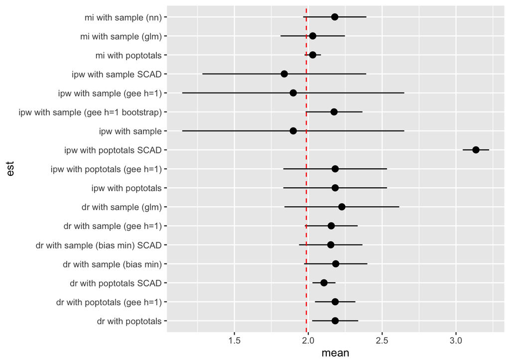

```r
ggplot(data = tab_res, aes(x = est, y = mean, ymin = lower_bound, ymax = upper_bound)) +
  geom_point() +
  geom_pointrange() +
  geom_hline(yintercept = y_true, linetype = "dashed", color = "red") +
  coord_flip()
```

## 6 Literature

Yang, Shu, Jae Kwang Kim, and Rui Song. 2020. “Doubly Robust Inference When Combining Probability and Non-Probability Samples with High Dimensional Data.” *Journal of the Royal Statistical Society Series B: Statistical Methodology* 82 (2): 445–65. https://doi.org/10.1111/rssb.12354.